# Risk Factor Analysis

## Outcome Variable

**Outcome Variable:** ever_sstunted

## Predictor Variables

**Intervention Variable:** hhwealth_quart

**Adjustment Set:**

- arm
- sex
- W_mage
- meducyrs
- feducyrs
- W_gagebrth
- W_birthwt
- W_birthlen
- W_nchldlt5
- W_parity
- delta_W_mage
- delta_meducyrs
- delta_feducyrs
- delta_W_gagebrth
- delta_W_birthwt
- delta_W_birthlen
- delta_W_nchldlt5
- delta_W_parity

## Stratifying Variables

The analysis was stratified on these variable(s):

- agecat
- studyid
- country

## Data Summary

| agecat | studyid | country | hhwealth_quart | ever_sstunted | n_cell | n |
| --- | --- | --- | --- | --- | --- | --- |
| 0-24 months | ki0047075b-MAL-ED | BANGLADESH | Wealth Q4 | 0 | 19 | 82 |
| 0-24 months | ki0047075b-MAL-ED | BANGLADESH | Wealth Q4 | 1 | 2 | 82 |
| 0-24 months | ki0047075b-MAL-ED | BANGLADESH | Wealth Q1 | 0 | 13 | 82 |
| 0-24 months | ki0047075b-MAL-ED | BANGLADESH | Wealth Q1 | 1 | 8 | 82 |
| 0-24 months | ki0047075b-MAL-ED | BANGLADESH | Wealth Q2 | 0 | 13 | 82 |
| 0-24 months | ki0047075b-MAL-ED | BANGLADESH | Wealth Q2 | 1 | 7 | 82 |
| 0-24 months | ki0047075b-MAL-ED | BANGLADESH | Wealth Q3 | 0 | 14 | 82 |
| 0-24 months | ki0047075b-MAL-ED | BANGLADESH | Wealth Q3 | 1 | 6 | 82 |
| 0-24 months | ki0047075b-MAL-ED | INDIA | Wealth Q4 | 0 | 14 | 71 |
| 0-24 months | ki0047075b-MAL-ED | INDIA | Wealth Q4 | 1 | 4 | 71 |
| 0-24 months | ki0047075b-MAL-ED | INDIA | Wealth Q1 | 0 | 16 | 71 |
| 0-24 months | ki0047075b-MAL-ED | INDIA | Wealth Q1 | 1 | 3 | 71 |
| 0-24 months | ki0047075b-MAL-ED | INDIA | Wealth Q2 | 0 | 15 | 71 |
| 0-24 months | ki0047075b-MAL-ED | INDIA | Wealth Q2 | 1 | 2 | 71 |
| 0-24 months | ki0047075b-MAL-ED | INDIA | Wealth Q3 | 0 | 12 | 71 |
| 0-24 months | ki0047075b-MAL-ED | INDIA | Wealth Q3 | 1 | 5 | 71 |
| 0-24 months | ki0047075b-MAL-ED | NEPAL | Wealth Q4 | 0 | 11 | 42 |
| 0-24 months | ki0047075b-MAL-ED | NEPAL | Wealth Q4 | 1 | 0 | 42 |
| 0-24 months | ki0047075b-MAL-ED | NEPAL | Wealth Q1 | 0 | 11 | 42 |
| 0-24 months | ki0047075b-MAL-ED | NEPAL | Wealth Q1 | 1 | 0 | 42 |
| 0-24 months | ki0047075b-MAL-ED | NEPAL | Wealth Q2 | 0 | 6 | 42 |
| 0-24 months | ki0047075b-MAL-ED | NEPAL | Wealth Q2 | 1 | 4 | 42 |
| 0-24 months | ki0047075b-MAL-ED | NEPAL | Wealth Q3 | 0 | 10 | 42 |
| 0-24 months | ki0047075b-MAL-ED | NEPAL | Wealth Q3 | 1 | 0 | 42 |
| 0-24 months | ki0047075b-MAL-ED | PERU | Wealth Q4 | 0 | 5 | 37 |
| 0-24 months | ki0047075b-MAL-ED | PERU | Wealth Q4 | 1 | 5 | 37 |
| 0-24 months | ki0047075b-MAL-ED | PERU | Wealth Q1 | 0 | 8 | 37 |
| 0-24 months | ki0047075b-MAL-ED | PERU | Wealth Q1 | 1 | 1 | 37 |
| 0-24 months | ki0047075b-MAL-ED | PERU | Wealth Q2 | 0 | 4 | 37 |
| 0-24 months | ki0047075b-MAL-ED | PERU | Wealth Q2 | 1 | 5 | 37 |

[output cut: 242 more lines]

The following strata were considered:

- agecat: 0-24 months, studyid: ki0047075b-MAL-ED, country: BANGLADESH
- agecat: 0-24 months, studyid: ki0047075b-MAL-ED, country: INDIA
- agecat: 0-24 months, studyid: ki0047075b-MAL-ED, country: NEPAL
- agecat: 0-24 months, studyid: ki0047075b-MAL-ED, country: PERU
- agecat: 0-24 months, studyid: ki0047075b-MAL-ED, country: SOUTH AFRICA
- agecat: 0-24 months, studyid: ki0047075b-MAL-ED, country: TANZANIA, UNITED REPUBLIC OF
- agecat: 0-24 months, studyid: ki1000108-CMC-V-BCS-2002, country: INDIA
- agecat: 0-24 months, studyid: ki1000108-IRC, country: INDIA
- agecat: 0-24 months, studyid: ki1017093b-PROVIDE, country: BANGLADESH
- agecat: 0-24 months, studyid: ki1066203-TanzaniaChild2, country: TANZANIA, UNITED REPUBLIC OF
- agecat: 0-24 months, studyid: ki1113344-GMS-Nepal, country: NEPAL
- agecat: 0-24 months, studyid: ki1114097-CONTENT, country: PERU
- agecat: 0-24 months, studyid: ki1135781-COHORTS, country: GUATEMALA
- agecat: 0-24 months, studyid: ki1135781-COHORTS, country: PHILIPPINES
- agecat: 0-24 months, studyid: ki1148112-LCNI-5, country: MALAWI
- agecat: 0-24 months, studyid: kiGH5241-JiVitA-3, country: BANGLADESH
- agecat: 0-24 months, studyid: kiGH5241-JiVitA-4, country: BANGLADESH
- agecat: 0-6 months, studyid: ki0047075b-MAL-ED, country: BANGLADESH
- agecat: 0-6 months, studyid: ki0047075b-MAL-ED, country: INDIA
- agecat: 0-6 months, studyid: ki0047075b-MAL-ED, country: NEPAL
- agecat: 0-6 months, studyid: ki0047075b-MAL-ED, country: PERU
- agecat: 0-6 months, studyid: ki0047075b-MAL-ED, country: SOUTH AFRICA
- agecat: 0-6 months, studyid: ki0047075b-MAL-ED, country: TANZANIA, UNITED REPUBLIC OF
- agecat: 0-6 months, studyid: ki1000108-CMC-V-BCS-2002, country: INDIA
- agecat: 0-6 months, studyid: ki1000108-IRC, country: INDIA
- agecat: 0-6 months, studyid: ki1017093b-PROVIDE, country: BANGLADESH
- agecat: 0-6 months, studyid: ki1066203-TanzaniaChild2, country: TANZANIA, UNITED REPUBLIC OF
- agecat: 0-6 months, studyid: ki1113344-GMS-Nepal, country: NEPAL
- agecat: 0-6 months, studyid: ki1114097-CONTENT, country: PERU
- agecat: 0-6 months, studyid: ki1135781-COHORTS, country: GUATEMALA
- agecat: 0-6 months, studyid: ki1135781-COHORTS, country: PHILIPPINES
- agecat: 0-6 months, studyid: ki1148112-LCNI-5, country: MALAWI
- agecat: 0-6 months, studyid: kiGH5241-JiVitA-3, country: BANGLADESH
- agecat: 0-6 months, studyid: kiGH5241-JiVitA-4, country: BANGLADESH

### Dropped Strata

Some strata were dropped due to rare outcomes:

- agecat: 0-24 months, studyid: ki0047075b-MAL-ED, country: BANGLADESH
- agecat: 0-24 months, studyid: ki0047075b-MAL-ED, country: INDIA
- agecat: 0-24 months, studyid: ki0047075b-MAL-ED, country: NEPAL
- agecat: 0-24 months, studyid: ki0047075b-MAL-ED, country: PERU
- agecat: 0-24 months, studyid: ki0047075b-MAL-ED, country: SOUTH AFRICA
- agecat: 0-24 months, studyid: ki1114097-CONTENT, country: PERU
- agecat: 0-6 months, studyid: ki0047075b-MAL-ED, country: BANGLADESH
- agecat: 0-6 months, studyid: ki0047075b-MAL-ED, country: INDIA
- agecat: 0-6 months, studyid: ki0047075b-MAL-ED, country: NEPAL
- agecat: 0-6 months, studyid: ki0047075b-MAL-ED, country: PERU
- agecat: 0-6 months, studyid: ki0047075b-MAL-ED, country: SOUTH AFRICA
- agecat: 0-6 months, studyid: ki0047075b-MAL-ED, country: TANZANIA, UNITED REPUBLIC OF
- agecat: 0-6 months, studyid: ki1017093b-PROVIDE, country: BANGLADESH
- agecat: 0-6 months, studyid: ki1114097-CONTENT, country: PERU
- agecat: 0-6 months, studyid: ki1148112-LCNI-5, country: MALAWI

## Methods Detail

We’re interested in the causal parameters $E[Y_a]$ for all values of $a \in \mathcal{A}$. These parameters represent the mean outcome if, possibly contrary to fact, we intervened to set all units to have $A=a$. Under the randomization and positivity assumptions, these are identified by the statistical parameters $\psi_a=E_W[E_{Y|A,W}(Y|A=a,W)]$. In addition, we’re interested in the mean of $Y$, $E[Y]$ under no intervention (the observed mean). We will estimate these parameters by using SuperLearner to fit the relevant likelihood factors – $E_{Y|A,W}(Y|A=a,W)$ and $p(A=a|W)$, and then updating our likelihood fit using a joint TMLE.

For unadjusted analyses ($W=\{\}$), initial likelihoods were estimated using Lrnr_glm to estimate the simple $E(Y|A)$ and Lrnr_mean to estimate $p(A)$. For adjusted analyses, a small library containing Lrnr_glmnet, Lrnr_xgboost, and Lrnr_mean was used.

Having estimated these parameters, we will then use the delta method to estimate relative risks and attributable risks relative to a prespecified baseline level of $A$.

# Results Detail

## Results Plots

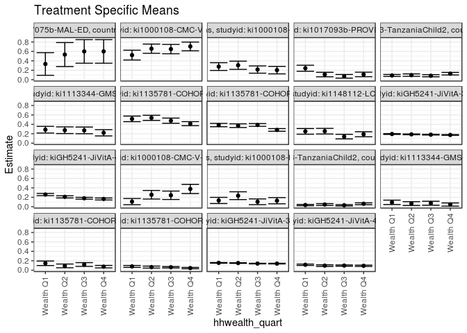

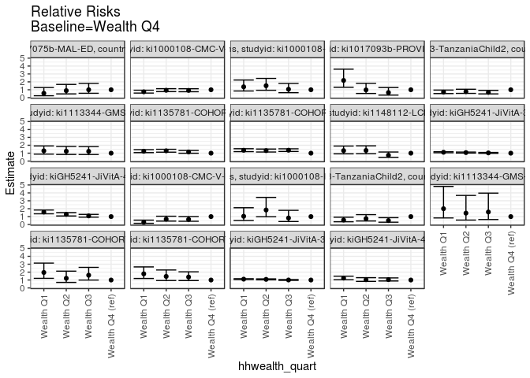

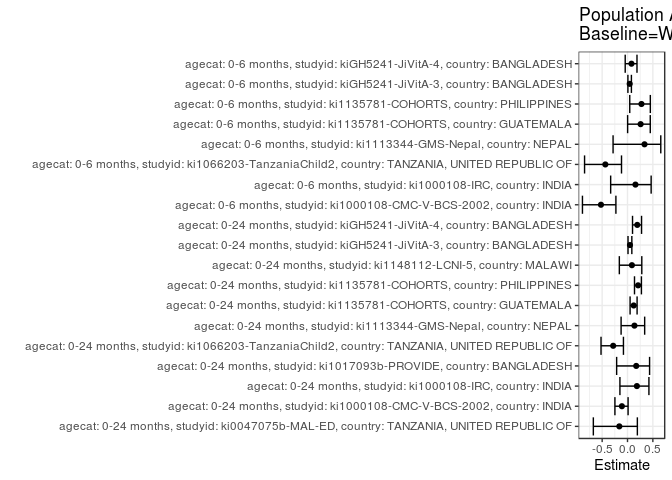

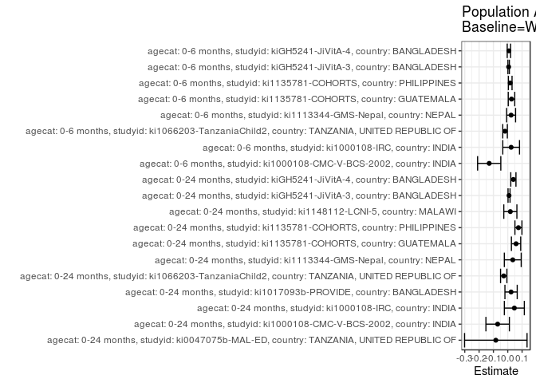

## Results Table

### Parameter: TSM

| agecat | studyid | country | intervention_level | baseline_level | estimate | ci_lower | ci_upper |
| --- | --- | --- | --- | --- | --- | --- | --- |
| 0-24 months | ki0047075b-MAL-ED | TANZANIA, UNITED REPUBLIC OF | Wealth Q4 | NA | 0.6000000 | 0.3499898 | 0.8500102 |
| 0-24 months | ki0047075b-MAL-ED | TANZANIA, UNITED REPUBLIC OF | Wealth Q1 | NA | 0.3333333 | 0.0927609 | 0.5739057 |
| 0-24 months | ki0047075b-MAL-ED | TANZANIA, UNITED REPUBLIC OF | Wealth Q2 | NA | 0.5333333 | 0.2787354 | 0.7879312 |
| 0-24 months | ki0047075b-MAL-ED | TANZANIA, UNITED REPUBLIC OF | Wealth Q3 | NA | 0.6000000 | 0.3499898 | 0.8500102 |
| 0-24 months | ki1000108-CMC-V-BCS-2002 | INDIA | Wealth Q4 | NA | 0.7058744 | 0.6128612 | 0.7988877 |
| 0-24 months | ki1000108-CMC-V-BCS-2002 | INDIA | Wealth Q1 | NA | 0.5218371 | 0.4175620 | 0.6261121 |
| 0-24 months | ki1000108-CMC-V-BCS-2002 | INDIA | Wealth Q2 | NA | 0.6579925 | 0.5601622 | 0.7558228 |
| 0-24 months | ki1000108-CMC-V-BCS-2002 | INDIA | Wealth Q3 | NA | 0.6494688 | 0.5504494 | 0.7484882 |
| 0-24 months | ki1000108-IRC | INDIA | Wealth Q4 | NA | 0.2027369 | 0.1232238 | 0.2822501 |
| 0-24 months | ki1000108-IRC | INDIA | Wealth Q1 | NA | 0.2781027 | 0.1957101 | 0.3604952 |
| 0-24 months | ki1000108-IRC | INDIA | Wealth Q2 | NA | 0.3061433 | 0.2193059 | 0.3929807 |
| 0-24 months | ki1000108-IRC | INDIA | Wealth Q3 | NA | 0.2152124 | 0.1380787 | 0.2923460 |
| 0-24 months | ki1017093b-PROVIDE | BANGLADESH | Wealth Q4 | NA | 0.1115027 | 0.0636594 | 0.1593460 |
| 0-24 months | ki1017093b-PROVIDE | BANGLADESH | Wealth Q1 | NA | 0.2429542 | 0.1793729 | 0.3065355 |
| 0-24 months | ki1017093b-PROVIDE | BANGLADESH | Wealth Q2 | NA | 0.1093362 | 0.0615518 | 0.1571206 |
| 0-24 months | ki1017093b-PROVIDE | BANGLADESH | Wealth Q3 | NA | 0.0719296 | 0.0333014 | 0.1105579 |
| 0-24 months | ki1066203-TanzaniaChild2 | TANZANIA, UNITED REPUBLIC OF | Wealth Q4 | NA | 0.1274794 | 0.1009133 | 0.1540455 |
| 0-24 months | ki1066203-TanzaniaChild2 | TANZANIA, UNITED REPUBLIC OF | Wealth Q1 | NA | 0.0899824 | 0.0694887 | 0.1104761 |
| 0-24 months | ki1066203-TanzaniaChild2 | TANZANIA, UNITED REPUBLIC OF | Wealth Q2 | NA | 0.0969352 | 0.0709300 | 0.1229404 |
| 0-24 months | ki1066203-TanzaniaChild2 | TANZANIA, UNITED REPUBLIC OF | Wealth Q3 | NA | 0.0842909 | 0.0619654 | 0.1066163 |
| 0-24 months | ki1113344-GMS-Nepal | NEPAL | Wealth Q4 | NA | 0.2208159 | 0.1543749 | 0.2872568 |
| 0-24 months | ki1113344-GMS-Nepal | NEPAL | Wealth Q1 | NA | 0.2869113 | 0.2155626 | 0.3582600 |
| 0-24 months | ki1113344-GMS-Nepal | NEPAL | Wealth Q2 | NA | 0.2753209 | 0.2042217 | 0.3464201 |
| 0-24 months | ki1113344-GMS-Nepal | NEPAL | Wealth Q3 | NA | 0.2719526 | 0.2010905 | 0.3428147 |
| 0-24 months | ki1135781-COHORTS | GUATEMALA | Wealth Q4 | NA | 0.4146252 | 0.3722940 | 0.4569564 |
| 0-24 months | ki1135781-COHORTS | GUATEMALA | Wealth Q1 | NA | 0.5158880 | 0.4564858 | 0.5752901 |
| 0-24 months | ki1135781-COHORTS | GUATEMALA | Wealth Q2 | NA | 0.5378613 | 0.4830133 | 0.5927093 |
| 0-24 months | ki1135781-COHORTS | GUATEMALA | Wealth Q3 | NA | 0.4779528 | 0.4231347 | 0.5327709 |
| 0-24 months | ki1135781-COHORTS | PHILIPPINES | Wealth Q4 | NA | 0.2817159 | 0.2535815 | 0.3098504 |
| 0-24 months | ki1135781-COHORTS | PHILIPPINES | Wealth Q1 | NA | 0.3852288 | 0.3494980 | 0.4209596 |
| 0-24 months | ki1135781-COHORTS | PHILIPPINES | Wealth Q2 | NA | 0.3724216 | 0.3336000 | 0.4112432 |
| 0-24 months | ki1135781-COHORTS | PHILIPPINES | Wealth Q3 | NA | 0.3872720 | 0.3578006 | 0.4167434 |
| 0-24 months | ki1148112-LCNI-5 | MALAWI | Wealth Q4 | NA | 0.1899969 | 0.1373843 | 0.2426095 |
| 0-24 months | ki1148112-LCNI-5 | MALAWI | Wealth Q1 | NA | 0.2512843 | 0.1913025 | 0.3112660 |
| 0-24 months | ki1148112-LCNI-5 | MALAWI | Wealth Q2 | NA | 0.2550221 | 0.1950548 | 0.3149894 |
| 0-24 months | ki1148112-LCNI-5 | MALAWI | Wealth Q3 | NA | 0.1399110 | 0.0914893 | 0.1883326 |
| 0-24 months | kiGH5241-JiVitA-3 | BANGLADESH | Wealth Q4 | NA | 0.1749032 | 0.1657349 | 0.1840715 |
| 0-24 months | kiGH5241-JiVitA-3 | BANGLADESH | Wealth Q1 | NA | 0.1948775 | 0.1867188 | 0.2030362 |
| 0-24 months | kiGH5241-JiVitA-3 | BANGLADESH | Wealth Q2 | NA | 0.1880139 | 0.1800248 | 0.1960030 |
| 0-24 months | kiGH5241-JiVitA-3 | BANGLADESH | Wealth Q3 | NA | 0.1810031 | 0.1732920 | 0.1887142 |
| 0-24 months | kiGH5241-JiVitA-4 | BANGLADESH | Wealth Q4 | NA | 0.1640665 | 0.1431547 | 0.1849782 |
| 0-24 months | kiGH5241-JiVitA-4 | BANGLADESH | Wealth Q1 | NA | 0.2584641 | 0.2354584 | 0.2814699 |
| 0-24 months | kiGH5241-JiVitA-4 | BANGLADESH | Wealth Q2 | NA | 0.2089389 | 0.1857692 | 0.2321086 |
| 0-24 months | kiGH5241-JiVitA-4 | BANGLADESH | Wealth Q3 | NA | 0.1788122 | 0.1596245 | 0.1980000 |
| 0-6 months | ki1000108-CMC-V-BCS-2002 | INDIA | Wealth Q4 | NA | 0.3767359 | 0.2790521 | 0.4744196 |
| 0-6 months | ki1000108-CMC-V-BCS-2002 | INDIA | Wealth Q1 | NA | 0.1081769 | 0.0431485 | 0.1732053 |
| 0-6 months | ki1000108-CMC-V-BCS-2002 | INDIA | Wealth Q2 | NA | 0.2537595 | 0.1628867 | 0.3446323 |
| 0-6 months | ki1000108-CMC-V-BCS-2002 | INDIA | Wealth Q3 | NA | 0.2422771 | 0.1531987 | 0.3313556 |
| 0-6 months | ki1000108-IRC | INDIA | Wealth Q4 | NA | 0.1275153 | 0.0616015 | 0.1934292 |
| 0-6 months | ki1000108-IRC | INDIA | Wealth Q1 | NA | 0.1326732 | 0.0670684 | 0.1982779 |
| 0-6 months | ki1000108-IRC | INDIA | Wealth Q2 | NA | 0.2338554 | 0.1506825 | 0.3170284 |
| 0-6 months | ki1000108-IRC | INDIA | Wealth Q3 | NA | 0.1048626 | 0.0439328 | 0.1657924 |
| 0-6 months | ki1066203-TanzaniaChild2 | TANZANIA, UNITED REPUBLIC OF | Wealth Q4 | NA | 0.0620944 | 0.0425904 | 0.0815985 |
| 0-6 months | ki1066203-TanzaniaChild2 | TANZANIA, UNITED REPUBLIC OF | Wealth Q1 | NA | 0.0351170 | 0.0217570 | 0.0484769 |
| 0-6 months | ki1066203-TanzaniaChild2 | TANZANIA, UNITED REPUBLIC OF | Wealth Q2 | NA | 0.0462859 | 0.0274708 | 0.0651010 |
| 0-6 months | ki1066203-TanzaniaChild2 | TANZANIA, UNITED REPUBLIC OF | Wealth Q3 | NA | 0.0310153 | 0.0170434 | 0.0449873 |
| 0-6 months | ki1113344-GMS-Nepal | NEPAL | Wealth Q4 | NA | 0.0463576 | 0.0127936 | 0.0799216 |
| 0-6 months | ki1113344-GMS-Nepal | NEPAL | Wealth Q1 | NA | 0.0927152 | 0.0464166 | 0.1390138 |
| 0-6 months | ki1113344-GMS-Nepal | NEPAL | Wealth Q2 | NA | 0.0666667 | 0.0267149 | 0.1066185 |
| 0-6 months | ki1113344-GMS-Nepal | NEPAL | Wealth Q3 | NA | 0.0733333 | 0.0315815 | 0.1150852 |
| 0-6 months | ki1135781-COHORTS | GUATEMALA | Wealth Q4 | NA | 0.0750695 | 0.0486468 | 0.1014921 |
| 0-6 months | ki1135781-COHORTS | GUATEMALA | Wealth Q1 | NA | 0.1467819 | 0.0993326 | 0.1942312 |
| 0-6 months | ki1135781-COHORTS | GUATEMALA | Wealth Q2 | NA | 0.0914958 | 0.0518222 | 0.1311694 |
| 0-6 months | ki1135781-COHORTS | GUATEMALA | Wealth Q3 | NA | 0.1207442 | 0.0807168 | 0.1607717 |
| 0-6 months | ki1135781-COHORTS | PHILIPPINES | Wealth Q4 | NA | 0.0452876 | 0.0312735 | 0.0593016 |
| 0-6 months | ki1135781-COHORTS | PHILIPPINES | Wealth Q1 | NA | 0.0808124 | 0.0603499 | 0.1012750 |
| 0-6 months | ki1135781-COHORTS | PHILIPPINES | Wealth Q2 | NA | 0.0660273 | 0.0449091 | 0.0871454 |
| 0-6 months | ki1135781-COHORTS | PHILIPPINES | Wealth Q3 | NA | 0.0624714 | 0.0473850 | 0.0775577 |
| 0-6 months | kiGH5241-JiVitA-3 | BANGLADESH | Wealth Q4 | NA | 0.1404151 | 0.1332272 | 0.1476030 |
| 0-6 months | kiGH5241-JiVitA-3 | BANGLADESH | Wealth Q1 | NA | 0.1558541 | 0.1492098 | 0.1624983 |
| 0-6 months | kiGH5241-JiVitA-3 | BANGLADESH | Wealth Q2 | NA | 0.1522360 | 0.1452935 | 0.1591785 |
| 0-6 months | kiGH5241-JiVitA-3 | BANGLADESH | Wealth Q3 | NA | 0.1412089 | 0.1344766 | 0.1479411 |
| 0-6 months | kiGH5241-JiVitA-4 | BANGLADESH | Wealth Q4 | NA | 0.0935023 | 0.0793294 | 0.1076752 |
| 0-6 months | kiGH5241-JiVitA-4 | BANGLADESH | Wealth Q1 | NA | 0.1159063 | 0.1010759 | 0.1307367 |
| 0-6 months | kiGH5241-JiVitA-4 | BANGLADESH | Wealth Q2 | NA | 0.0970794 | 0.0798373 | 0.1143214 |
| 0-6 months | kiGH5241-JiVitA-4 | BANGLADESH | Wealth Q3 | NA | 0.0986792 | 0.0849904 | 0.1123681 |

### Parameter: E(Y)

| agecat | studyid | country | intervention_level | baseline_level | estimate | ci_lower | ci_upper |
| --- | --- | --- | --- | --- | --- | --- | --- |
| 0-24 months | ki0047075b-MAL-ED | TANZANIA, UNITED REPUBLIC OF | NA | NA | 0.5166667 | 0.3891548 | 0.6441786 |
| 0-24 months | ki1000108-CMC-V-BCS-2002 | INDIA | NA | NA | 0.6353887 | 0.5864772 | 0.6843003 |
| 0-24 months | ki1000108-IRC | INDIA | NA | NA | 0.2487805 | 0.2068840 | 0.2906770 |
| 0-24 months | ki1017093b-PROVIDE | BANGLADESH | NA | NA | 0.1346705 | 0.1093274 | 0.1600135 |
| 0-24 months | ki1066203-TanzaniaChild2 | TANZANIA, UNITED REPUBLIC OF | NA | NA | 0.0994128 | 0.0873992 | 0.1114263 |
| 0-24 months | ki1113344-GMS-Nepal | NEPAL | NA | NA | 0.2558140 | 0.2209310 | 0.2906969 |
| 0-24 months | ki1135781-COHORTS | GUATEMALA | NA | NA | 0.4726135 | 0.4452311 | 0.4999958 |
| 0-24 months | ki1135781-COHORTS | PHILIPPINES | NA | NA | 0.3562316 | 0.3392530 | 0.3732102 |
| 0-24 months | ki1148112-LCNI-5 | MALAWI | NA | NA | 0.2080783 | 0.1802263 | 0.2359304 |
| 0-24 months | kiGH5241-JiVitA-3 | BANGLADESH | NA | NA | 0.1838160 | 0.1782391 | 0.1893929 |
| 0-24 months | kiGH5241-JiVitA-4 | BANGLADESH | NA | NA | 0.2032805 | 0.1914625 | 0.2150985 |
| 0-6 months | ki1000108-CMC-V-BCS-2002 | INDIA | NA | NA | 0.2472826 | 0.2031431 | 0.2914222 |
| 0-6 months | ki1000108-IRC | INDIA | NA | NA | 0.1512195 | 0.1164988 | 0.1859402 |
| 0-6 months | ki1066203-TanzaniaChild2 | TANZANIA, UNITED REPUBLIC OF | NA | NA | 0.0432047 | 0.0350415 | 0.0513679 |
| 0-6 months | ki1113344-GMS-Nepal | NEPAL | NA | NA | 0.0697674 | 0.0494002 | 0.0901347 |
| 0-6 months | ki1135781-COHORTS | GUATEMALA | NA | NA | 0.1012536 | 0.0828843 | 0.1196229 |
| 0-6 months | ki1135781-COHORTS | PHILIPPINES | NA | NA | 0.0624796 | 0.0538987 | 0.0710604 |
| 0-6 months | kiGH5241-JiVitA-3 | BANGLADESH | NA | NA | 0.1467251 | 0.1417113 | 0.1517389 |
| 0-6 months | kiGH5241-JiVitA-4 | BANGLADESH | NA | NA | 0.1014266 | 0.0924810 | 0.1103722 |

### Parameter: RR

| agecat | studyid | country | intervention_level | baseline_level | estimate | ci_lower | ci_upper |
| --- | --- | --- | --- | --- | --- | --- | --- |
| 0-24 months | ki0047075b-MAL-ED | TANZANIA, UNITED REPUBLIC OF | Wealth Q4 | Wealth Q4 | 1.0000000 | 1.0000000 | 1.0000000 |
| 0-24 months | ki0047075b-MAL-ED | TANZANIA, UNITED REPUBLIC OF | Wealth Q1 | Wealth Q4 | 0.5555556 | 0.2414353 | 1.2783633 |
| 0-24 months | ki0047075b-MAL-ED | TANZANIA, UNITED REPUBLIC OF | Wealth Q2 | Wealth Q4 | 0.8888889 | 0.4716916 | 1.6750849 |
| 0-24 months | ki0047075b-MAL-ED | TANZANIA, UNITED REPUBLIC OF | Wealth Q3 | Wealth Q4 | 1.0000000 | 0.5547267 | 1.8026894 |
| 0-24 months | ki1000108-CMC-V-BCS-2002 | INDIA | Wealth Q4 | Wealth Q4 | 1.0000000 | 1.0000000 | 1.0000000 |
| 0-24 months | ki1000108-CMC-V-BCS-2002 | INDIA | Wealth Q1 | Wealth Q4 | 0.7392775 | 0.5818059 | 0.9393704 |
| 0-24 months | ki1000108-CMC-V-BCS-2002 | INDIA | Wealth Q2 | Wealth Q4 | 0.9321665 | 0.7641135 | 1.1371799 |
| 0-24 months | ki1000108-CMC-V-BCS-2002 | INDIA | Wealth Q3 | Wealth Q4 | 0.9200911 | 0.7522212 | 1.1254238 |
| 0-24 months | ki1000108-IRC | INDIA | Wealth Q4 | Wealth Q4 | 1.0000000 | 1.0000000 | 1.0000000 |
| 0-24 months | ki1000108-IRC | INDIA | Wealth Q1 | Wealth Q4 | 1.3717416 | 0.8422816 | 2.2340212 |
| 0-24 months | ki1000108-IRC | INDIA | Wealth Q2 | Wealth Q4 | 1.5100519 | 0.9360012 | 2.4361684 |
| 0-24 months | ki1000108-IRC | INDIA | Wealth Q3 | Wealth Q4 | 1.0615351 | 0.6273762 | 1.7961421 |
| 0-24 months | ki1017093b-PROVIDE | BANGLADESH | Wealth Q4 | Wealth Q4 | 1.0000000 | 1.0000000 | 1.0000000 |
| 0-24 months | ki1017093b-PROVIDE | BANGLADESH | Wealth Q1 | Wealth Q4 | 2.1789087 | 1.3174602 | 3.6036330 |
| 0-24 months | ki1017093b-PROVIDE | BANGLADESH | Wealth Q2 | Wealth Q4 | 0.9805700 | 0.5312413 | 1.8099450 |
| 0-24 months | ki1017093b-PROVIDE | BANGLADESH | Wealth Q3 | Wealth Q4 | 0.6450934 | 0.3243116 | 1.2831657 |
| 0-24 months | ki1066203-TanzaniaChild2 | TANZANIA, UNITED REPUBLIC OF | Wealth Q4 | Wealth Q4 | 1.0000000 | 1.0000000 | 1.0000000 |
| 0-24 months | ki1066203-TanzaniaChild2 | TANZANIA, UNITED REPUBLIC OF | Wealth Q1 | Wealth Q4 | 0.7058582 | 0.5196866 | 0.9587237 |
| 0-24 months | ki1066203-TanzaniaChild2 | TANZANIA, UNITED REPUBLIC OF | Wealth Q2 | Wealth Q4 | 0.7603990 | 0.5425432 | 1.0657339 |
| 0-24 months | ki1066203-TanzaniaChild2 | TANZANIA, UNITED REPUBLIC OF | Wealth Q3 | Wealth Q4 | 0.6612118 | 0.4729697 | 0.9243742 |
| 0-24 months | ki1113344-GMS-Nepal | NEPAL | Wealth Q4 | Wealth Q4 | 1.0000000 | 1.0000000 | 1.0000000 |
| 0-24 months | ki1113344-GMS-Nepal | NEPAL | Wealth Q1 | Wealth Q4 | 1.2993237 | 0.8794204 | 1.9197214 |
| 0-24 months | ki1113344-GMS-Nepal | NEPAL | Wealth Q2 | Wealth Q4 | 1.2468346 | 0.8385490 | 1.8539126 |
| 0-24 months | ki1113344-GMS-Nepal | NEPAL | Wealth Q3 | Wealth Q4 | 1.2315809 | 0.8273898 | 1.8332246 |
| 0-24 months | ki1135781-COHORTS | GUATEMALA | Wealth Q4 | Wealth Q4 | 1.0000000 | 1.0000000 | 1.0000000 |
| 0-24 months | ki1135781-COHORTS | GUATEMALA | Wealth Q1 | Wealth Q4 | 1.2442272 | 1.0698841 | 1.4469804 |
| 0-24 months | ki1135781-COHORTS | GUATEMALA | Wealth Q2 | Wealth Q4 | 1.2972228 | 1.1271919 | 1.4929021 |
| 0-24 months | ki1135781-COHORTS | GUATEMALA | Wealth Q3 | Wealth Q4 | 1.1527345 | 0.9921763 | 1.3392750 |
| 0-24 months | ki1135781-COHORTS | PHILIPPINES | Wealth Q4 | Wealth Q4 | 1.0000000 | 1.0000000 | 1.0000000 |
| 0-24 months | ki1135781-COHORTS | PHILIPPINES | Wealth Q1 | Wealth Q4 | 1.3674369 | 1.1961783 | 1.5632148 |
| 0-24 months | ki1135781-COHORTS | PHILIPPINES | Wealth Q2 | Wealth Q4 | 1.3219756 | 1.1476085 | 1.5228359 |
| 0-24 months | ki1135781-COHORTS | PHILIPPINES | Wealth Q3 | Wealth Q4 | 1.3746897 | 1.2159502 | 1.5541523 |
| 0-24 months | ki1148112-LCNI-5 | MALAWI | Wealth Q4 | Wealth Q4 | 1.0000000 | 1.0000000 | 1.0000000 |
| 0-24 months | ki1148112-LCNI-5 | MALAWI | Wealth Q1 | Wealth Q4 | 1.3225704 | 0.9174181 | 1.9066470 |
| 0-24 months | ki1148112-LCNI-5 | MALAWI | Wealth Q2 | Wealth Q4 | 1.3422432 | 0.9330891 | 1.9308090 |
| 0-24 months | ki1148112-LCNI-5 | MALAWI | Wealth Q3 | Wealth Q4 | 0.7363854 | 0.4730004 | 1.1464335 |
| 0-24 months | kiGH5241-JiVitA-3 | BANGLADESH | Wealth Q4 | Wealth Q4 | 1.0000000 | 1.0000000 | 1.0000000 |
| 0-24 months | kiGH5241-JiVitA-3 | BANGLADESH | Wealth Q1 | Wealth Q4 | 1.1142022 | 1.0547914 | 1.1769594 |
| 0-24 months | kiGH5241-JiVitA-3 | BANGLADESH | Wealth Q2 | Wealth Q4 | 1.0749601 | 1.0143191 | 1.1392264 |
| 0-24 months | kiGH5241-JiVitA-3 | BANGLADESH | Wealth Q3 | Wealth Q4 | 1.0348762 | 0.9795913 | 1.0932811 |
| 0-24 months | kiGH5241-JiVitA-4 | BANGLADESH | Wealth Q4 | Wealth Q4 | 1.0000000 | 1.0000000 | 1.0000000 |
| 0-24 months | kiGH5241-JiVitA-4 | BANGLADESH | Wealth Q1 | Wealth Q4 | 1.5753623 | 1.3557074 | 1.8306062 |
| 0-24 months | kiGH5241-JiVitA-4 | BANGLADESH | Wealth Q2 | Wealth Q4 | 1.2735015 | 1.0786180 | 1.5035965 |
| 0-24 months | kiGH5241-JiVitA-4 | BANGLADESH | Wealth Q3 | Wealth Q4 | 1.0898768 | 0.9287577 | 1.2789464 |
| 0-6 months | ki1000108-CMC-V-BCS-2002 | INDIA | Wealth Q4 | Wealth Q4 | 1.0000000 | 1.0000000 | 1.0000000 |
| 0-6 months | ki1000108-CMC-V-BCS-2002 | INDIA | Wealth Q1 | Wealth Q4 | 0.2871425 | 0.1491218 | 0.5529095 |
| 0-6 months | ki1000108-CMC-V-BCS-2002 | INDIA | Wealth Q2 | Wealth Q4 | 0.6735741 | 0.4331543 | 1.0474374 |
| 0-6 months | ki1000108-CMC-V-BCS-2002 | INDIA | Wealth Q3 | Wealth Q4 | 0.6430955 | 0.4105132 | 1.0074509 |
| 0-6 months | ki1000108-IRC | INDIA | Wealth Q4 | Wealth Q4 | 1.0000000 | 1.0000000 | 1.0000000 |
| 0-6 months | ki1000108-IRC | INDIA | Wealth Q1 | Wealth Q4 | 1.0404486 | 0.5104087 | 2.1209149 |
| 0-6 months | ki1000108-IRC | INDIA | Wealth Q2 | Wealth Q4 | 1.8339398 | 0.9804034 | 3.4305628 |
| 0-6 months | ki1000108-IRC | INDIA | Wealth Q3 | Wealth Q4 | 0.8223526 | 0.3776635 | 1.7906521 |
| 0-6 months | ki1066203-TanzaniaChild2 | TANZANIA, UNITED REPUBLIC OF | Wealth Q4 | Wealth Q4 | 1.0000000 | 1.0000000 | 1.0000000 |
| 0-6 months | ki1066203-TanzaniaChild2 | TANZANIA, UNITED REPUBLIC OF | Wealth Q1 | Wealth Q4 | 0.5655414 | 0.3458425 | 0.9248057 |
| 0-6 months | ki1066203-TanzaniaChild2 | TANZANIA, UNITED REPUBLIC OF | Wealth Q2 | Wealth Q4 | 0.7454107 | 0.4460514 | 1.2456795 |
| 0-6 months | ki1066203-TanzaniaChild2 | TANZANIA, UNITED REPUBLIC OF | Wealth Q3 | Wealth Q4 | 0.4994863 | 0.2885901 | 0.8645017 |
| 0-6 months | ki1113344-GMS-Nepal | NEPAL | Wealth Q4 | Wealth Q4 | 1.0000000 | 1.0000000 | 1.0000000 |
| 0-6 months | ki1113344-GMS-Nepal | NEPAL | Wealth Q1 | Wealth Q4 | 2.0000000 | 0.8299551 | 4.8195376 |
| 0-6 months | ki1113344-GMS-Nepal | NEPAL | Wealth Q2 | Wealth Q4 | 1.4380952 | 0.5618368 | 3.6809941 |
| 0-6 months | ki1113344-GMS-Nepal | NEPAL | Wealth Q3 | Wealth Q4 | 1.5819047 | 0.6297474 | 3.9736924 |
| 0-6 months | ki1135781-COHORTS | GUATEMALA | Wealth Q4 | Wealth Q4 | 1.0000000 | 1.0000000 | 1.0000000 |
| 0-6 months | ki1135781-COHORTS | GUATEMALA | Wealth Q1 | Wealth Q4 | 1.9552806 | 1.2160732 | 3.1438258 |
| 0-6 months | ki1135781-COHORTS | GUATEMALA | Wealth Q2 | Wealth Q4 | 1.2188150 | 0.6992552 | 2.1244175 |
| 0-6 months | ki1135781-COHORTS | GUATEMALA | Wealth Q3 | Wealth Q4 | 1.6084335 | 0.9934067 | 2.6042288 |
| 0-6 months | ki1135781-COHORTS | PHILIPPINES | Wealth Q4 | Wealth Q4 | 1.0000000 | 1.0000000 | 1.0000000 |
| 0-6 months | ki1135781-COHORTS | PHILIPPINES | Wealth Q1 | Wealth Q4 | 1.7844274 | 1.1972493 | 2.6595806 |
| 0-6 months | ki1135781-COHORTS | PHILIPPINES | Wealth Q2 | Wealth Q4 | 1.4579552 | 0.9357378 | 2.2716120 |
| 0-6 months | ki1135781-COHORTS | PHILIPPINES | Wealth Q3 | Wealth Q4 | 1.3794365 | 0.9331759 | 2.0391063 |
| 0-6 months | kiGH5241-JiVitA-3 | BANGLADESH | Wealth Q4 | Wealth Q4 | 1.0000000 | 1.0000000 | 1.0000000 |
| 0-6 months | kiGH5241-JiVitA-3 | BANGLADESH | Wealth Q1 | Wealth Q4 | 1.1099524 | 1.0554125 | 1.1673107 |
| 0-6 months | kiGH5241-JiVitA-3 | BANGLADESH | Wealth Q2 | Wealth Q4 | 1.0841856 | 1.0249492 | 1.1468455 |
| 0-6 months | kiGH5241-JiVitA-3 | BANGLADESH | Wealth Q3 | Wealth Q4 | 1.0056531 | 0.9535506 | 1.0606025 |
| 0-6 months | kiGH5241-JiVitA-4 | BANGLADESH | Wealth Q4 | Wealth Q4 | 1.0000000 | 1.0000000 | 1.0000000 |
| 0-6 months | kiGH5241-JiVitA-4 | BANGLADESH | Wealth Q1 | Wealth Q4 | 1.2396094 | 1.0337472 | 1.4864673 |
| 0-6 months | kiGH5241-JiVitA-4 | BANGLADESH | Wealth Q2 | Wealth Q4 | 1.0382567 | 0.8299506 | 1.2988448 |
| 0-6 months | kiGH5241-JiVitA-4 | BANGLADESH | Wealth Q3 | Wealth Q4 | 1.0553670 | 0.8794232 | 1.2665114 |

### Parameter: PAR

| agecat | studyid | country | intervention_level | baseline_level | estimate | ci_lower | ci_upper |
| --- | --- | --- | --- | --- | --- | --- | --- |
| 0-24 months | ki0047075b-MAL-ED | TANZANIA, UNITED REPUBLIC OF | Wealth Q4 | NA | -0.0833333 | -0.3013054 | 0.1346387 |
| 0-24 months | ki1000108-CMC-V-BCS-2002 | INDIA | Wealth Q4 | NA | -0.0704857 | -0.1523567 | 0.0113854 |
| 0-24 months | ki1000108-IRC | INDIA | Wealth Q4 | NA | 0.0460436 | -0.0236889 | 0.1157760 |
| 0-24 months | ki1017093b-PROVIDE | BANGLADESH | Wealth Q4 | NA | 0.0231678 | -0.0196865 | 0.0660221 |
| 0-24 months | ki1066203-TanzaniaChild2 | TANZANIA, UNITED REPUBLIC OF | Wealth Q4 | NA | -0.0280667 | -0.0501529 | -0.0059804 |
| 0-24 months | ki1113344-GMS-Nepal | NEPAL | Wealth Q4 | NA | 0.0349981 | -0.0238844 | 0.0938806 |
| 0-24 months | ki1135781-COHORTS | GUATEMALA | Wealth Q4 | NA | 0.0579883 | 0.0255158 | 0.0904607 |
| 0-24 months | ki1135781-COHORTS | PHILIPPINES | Wealth Q4 | NA | 0.0745157 | 0.0500893 | 0.0989420 |
| 0-24 months | ki1148112-LCNI-5 | MALAWI | Wealth Q4 | NA | 0.0180814 | -0.0275983 | 0.0637611 |
| 0-24 months | kiGH5241-JiVitA-3 | BANGLADESH | Wealth Q4 | NA | 0.0089128 | 0.0020140 | 0.0158116 |
| 0-24 months | kiGH5241-JiVitA-4 | BANGLADESH | Wealth Q4 | NA | 0.0392140 | 0.0211532 | 0.0572748 |
| 0-6 months | ki1000108-CMC-V-BCS-2002 | INDIA | Wealth Q4 | NA | -0.1294532 | -0.2104554 | -0.0484511 |
| 0-6 months | ki1000108-IRC | INDIA | Wealth Q4 | NA | 0.0237042 | -0.0347265 | 0.0821349 |
| 0-6 months | ki1066203-TanzaniaChild2 | TANZANIA, UNITED REPUBLIC OF | Wealth Q4 | NA | -0.0188897 | -0.0348726 | -0.0029069 |
| 0-6 months | ki1113344-GMS-Nepal | NEPAL | Wealth Q4 | NA | 0.0234098 | -0.0078348 | 0.0546544 |
| 0-6 months | ki1135781-COHORTS | GUATEMALA | Wealth Q4 | NA | 0.0261841 | 0.0035134 | 0.0488549 |
| 0-6 months | ki1135781-COHORTS | PHILIPPINES | Wealth Q4 | NA | 0.0171920 | 0.0044558 | 0.0299281 |
| 0-6 months | kiGH5241-JiVitA-3 | BANGLADESH | Wealth Q4 | NA | 0.0063100 | 0.0012586 | 0.0113615 |
| 0-6 months | kiGH5241-JiVitA-4 | BANGLADESH | Wealth Q4 | NA | 0.0079243 | -0.0038614 | 0.0197101 |

### Parameter: PAF

| agecat | studyid | country | intervention_level | baseline_level | estimate | ci_lower | ci_upper |
| --- | --- | --- | --- | --- | --- | --- | --- |
| 0-24 months | ki0047075b-MAL-ED | TANZANIA, UNITED REPUBLIC OF | Wealth Q4 | NA | -0.1612903 | -0.6739874 | 0.1943815 |
| 0-24 months | ki1000108-CMC-V-BCS-2002 | INDIA | Wealth Q4 | NA | -0.1109332 | -0.2484019 | 0.0113981 |
| 0-24 months | ki1000108-IRC | INDIA | Wealth Q4 | NA | 0.1850770 | -0.1496818 | 0.4223624 |
| 0-24 months | ki1017093b-PROVIDE | BANGLADESH | Wealth Q4 | NA | 0.1720333 | -0.2142441 | 0.4354274 |
| 0-24 months | ki1066203-TanzaniaChild2 | TANZANIA, UNITED REPUBLIC OF | Wealth Q4 | NA | -0.2823245 | -0.5223745 | -0.0801258 |
| 0-24 months | ki1113344-GMS-Nepal | NEPAL | Wealth Q4 | NA | 0.1368107 | -0.1263639 | 0.3384946 |
| 0-24 months | ki1135781-COHORTS | GUATEMALA | Wealth Q4 | NA | 0.1226970 | 0.0508828 | 0.1890774 |
| 0-24 months | ki1135781-COHORTS | PHILIPPINES | Wealth Q4 | NA | 0.2091776 | 0.1379831 | 0.2744921 |
| 0-24 months | ki1148112-LCNI-5 | MALAWI | Wealth Q4 | NA | 0.0868972 | -0.1611164 | 0.2819353 |
| 0-24 months | kiGH5241-JiVitA-3 | BANGLADESH | Wealth Q4 | NA | 0.0484876 | 0.0100701 | 0.0854142 |
| 0-24 months | kiGH5241-JiVitA-4 | BANGLADESH | Wealth Q4 | NA | 0.1929060 | 0.0990319 | 0.2769991 |
| 0-6 months | ki1000108-CMC-V-BCS-2002 | INDIA | Wealth Q4 | NA | -0.5235032 | -0.8887505 | -0.2288876 |
| 0-6 months | ki1000108-IRC | INDIA | Wealth Q4 | NA | 0.1567534 | -0.3321882 | 0.4662430 |
| 0-6 months | ki1066203-TanzaniaChild2 | TANZANIA, UNITED REPUBLIC OF | Wealth Q4 | NA | -0.4372151 | -0.8470572 | -0.1183125 |
| 0-6 months | ki1113344-GMS-Nepal | NEPAL | Wealth Q4 | NA | 0.3355408 | -0.2847112 | 0.6563383 |
| 0-6 months | ki1135781-COHORTS | GUATEMALA | Wealth Q4 | NA | 0.2585996 | 0.0022701 | 0.4490749 |
| 0-6 months | ki1135781-COHORTS | PHILIPPINES | Wealth Q4 | NA | 0.2751615 | 0.0441866 | 0.4503207 |
| 0-6 months | kiGH5241-JiVitA-3 | BANGLADESH | Wealth Q4 | NA | 0.0430058 | 0.0078884 | 0.0768802 |
| 0-6 months | kiGH5241-JiVitA-4 | BANGLADESH | Wealth Q4 | NA | 0.0781288 | -0.0452739 | 0.1869628 |